# Sleep Health and Lifestyle Analysis

## Introduction

This project explores how lifestyle, demographic, and health factors influence sleep quality, sleep duration, and the presence of sleep disorders. The goal is to uncover actionable insights that can help individuals improve their sleep health.

## Objectives

The objective of this analysis is to determine which lifestyle and health-related factors most significantly affect sleep health. It aims to:

- Identify trends and correlations.
- Highlight potential risk factors for sleep disorders.
- Offer data-driven recommendations.

## Key Questions

This project seeks to answer the following questions:

1. How does age correlate with sleep duration?
2. Do men and women report different sleep quality levels?
3. Are certain occupations more prone to sleep disorders?
4. Is there a pattern between occupation type and physical activity?
5. How does physical activity level impact sleep quality?
6. Is there a relationship between daily steps and sleep duration?
7. Do people with high stress levels sleep less or report poorer sleep quality?
8. Are people with higher physical activity levels less likely to have sleep disorders?
9. How does heart rate vary with sleep quality or disorders?
10. Is there a relationship between BMI and sleep duration or disorder occurrence?
11. Do people with healthy BMI ranges have better sleep?
12. What factors are most associated with short sleep duration (<6 hours)?
13. What predicts high sleep quality (>7/10)?
14. Which features are most predictive of having a sleep disorder?
15. Do people who walk more steps have lower stress and better sleep?
16. Can we recommend an optimal lifestyle profile (steps, activity level, BMI, stress) for better sleep?
17. Among individuals with high sleep quality, what are the common lifestyle patterns?
18. Which combinations of stress and activity result in the worst sleep?
19. Is there a threshold of daily steps beyond which sleep quality doesn’t improve?

## Dataset Overview

The dataset includes 374 observations and 13 variables (columns):

- Age (Numeric)
- Gender (Male/Female)
- Occupation (Categorical)
- Sleep Duration (Hours)
- Quality of Sleep (1–10)
- Physical Activity Level
- Stress Level (1–10)
- BMI
- Heart Rate
- Daily Steps
- Sleep Disorder (None, Insomnia, Apnea)

Source: [Kaggle](https://www.kaggle.com/datasets/uom190346a/sleep-health-and-lifestyle-dataset)

## Tools Used

The tools used for this project are:

- Excel for cleaning data.
- Power BI for visualisation.
- R script for documentation.

## Data Preparation

#### Data cleaning was initially done using Excel:

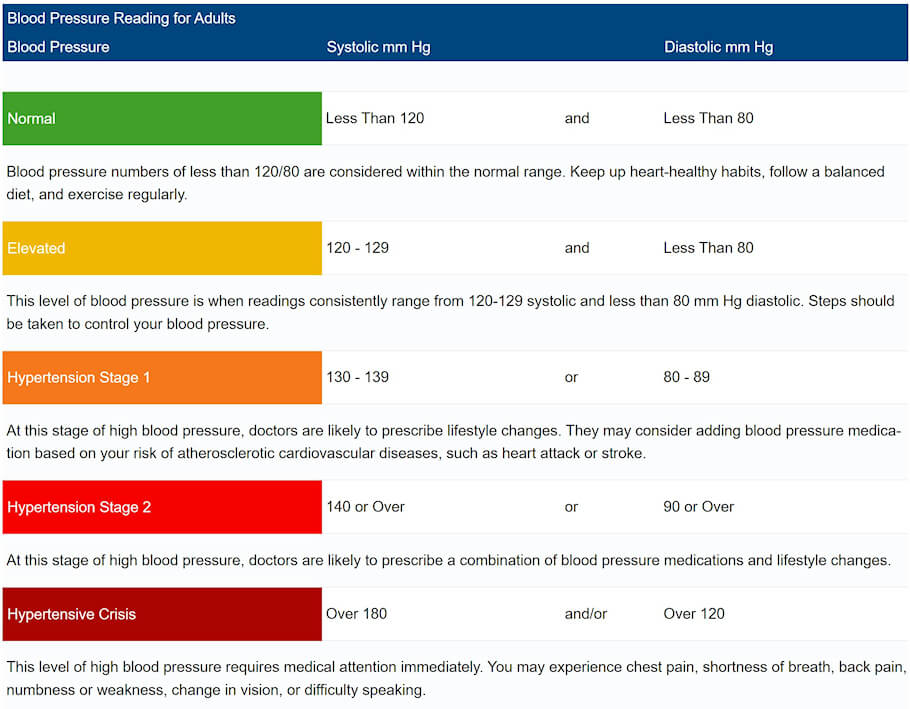

Blood pressure chart

- Categorised participants into sleeper types: Short sleeper, Normal sleeper and Excessive sleeper; based on the general recommendations of the [Cleveland Clinic](https://my.clevelandclinic.org/health/body/12148-sleep-basics), [Mayo Clinic](https://www.mayoclinic.org/healthy-lifestyle/adult-health/expert-answers/how-many-hours-of-sleep-are-enough/faq-20057898), and [Healthline](https://www.healthline.com/health/sleep/sleep-calculator).
- Categorised activity levels into the following: Very light activity, Light activity, Moderate activity, Vigorous activity, Very hard activity, Maximum effort activity based on classifications of the [American Physical Therapy Association](https://www.apta.org/patient-care/evidence-based-practice-resources/test-measures/omni-exertion-scale).

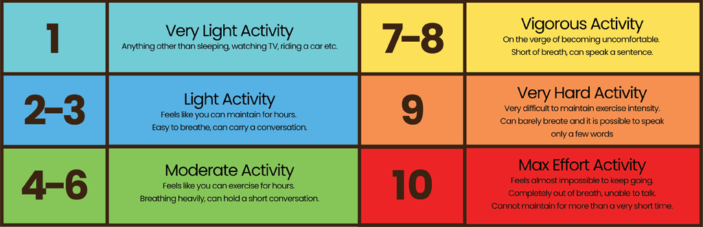

RPE scale

#### Further data processing was done in Power BI:

Created calculated columns and measures to allow for easy data summarisation

## Exploratory Analysis

[figure not shown]

Demographic data dashboard

- 25-29 year olds have the shortest sleep duration and 55+ year olds have the longest average sleep duration.
- Females have higher sleep quality(52%) than males (48%).
- Nurses report the highest levels of physical activity.
- The engineering professioin has the most people with no sleep disorders, the nursing profession has the most people suffering sleep apnea while the salesperson profession has the most people suffering insomnia.

[figure not shown]

Lifestyle data dashboard

- Sleep quality rises with physical activity levels and peaks between levels 80-85.
- Average daily steps is 6,820 steps.
- People who fall into the short sleeper category record below average daily steps, normal sleepers record the highest sleep duration at an average of 5000 daily steps.
- The highest level of insomnia is observed in people who engage in moderate level physical activity, the highest level of sleep apnea is observed in people who perform very hard activity and light physical activity has the most amount of people with no sleep disorders.
- The highest stress level (8) records the worst sleep quality (5.86) while the least stress level (3) records the best sleep quality (8.97).

[figure not shown]

Health metrics dashboard

- People in the Obese BMI category record the least sleep duration and quality while people in the normal BMI category record the highest sleep duration and quality.
- The average heart rate for subjects with the worst sleep quality (4) is 85bpm, the average heart rate for subjects with the best sleep quality (9) is 65.34bpm.
- Most participants with blood-pressure within the Normal,Elevated and Hypertension stage 1 categories experience no sleep disorder; sleep apnea is most prevalent in the Hypertension stage 2 category.

[figure not shown]

Sleep health dashboard

- Average sleep duration is 7.13 hours.
- The normal BMI category records the longest sleep duration whereas the obese category records the least.
- Stress level is observed to be lowest in Normal blood-pressure group and highest in the Elevated blood-pressure group.
- Sleep duration is observed to be lowest in Hypertension stage 2 blood-pressure group and longest in elevated blood-pressure group.
- The hypertension stage 2 category records the highest average daily steps for people experiencing sleep apnea as well as people experiencing no disorders, the normal blood pressure category on the other hand shows the highest daily steps for people experiencing insomnia.

[figure not shown]

Behavioral insights dashboard

- The best sleep quality and least stress level were observed at 6000 average daily steps,
- At stress level of 3, sleep quality is highest for light, very hard and vigorous activity levels.
- The obese and the overweight categories only have low sleep quality.

## Recommendations

- Encourage moderate to vigorous exercise routines across all age groups, aiming for at least 30 minutes per day. This supports both physical and sleep health.
- Professions with higher sleep disorder rates (for instance, teachers, nurses, sales attendants) may benefit from targeted stress reduction programs, flexible schedules, and wellness interventions.
- Stress management techniques such as mindfulness, relaxation, or counseling should be promoted, especially for high-stress groups.
- Support programs that help people achieve and maintain a normal BMI, as this is strongly linked to better sleep outcomes.
- Set realistic step goals. Promote walking goals in the range of 5,000–7,500 steps per day. Beyond this range, there may be less benefits. Consistent movement is more beneficial than step extremes.
- Individuals should be educated on how daily lifestyle factors impact sleep quality to allow them make small, sustainable changes.
- Use the optimal lifestyle profile (normal BMI, low stress, moderate-to-high physical activity, 7,500 steps/day) as a behavioral model in sleep health campaigns.
- Identify individuals with combinations of high BMI, low activity, and high stress as high risk for sleep disorders, and prioritise them for intervention.

## Conclusion

This analysis shows that sleep health is deeply influenced by lifestyle behaviors, including stress levels, physical activity, BMI, and daily habits. Age, gender, and occupation also play key roles in shaping sleep experiences for individuals.

Key findings suggest:

Future work could explore time-based patterns in data and take a look at some other lifestyle factors that may influence sleep. Like the effects of screen time before bed on sleep quality and duration, or investigate the outcomes between people who stick to consistent sleep schedules and those who do not. Or even observe the role of caffeine and/or diet in relation to stress and sleep quality. Integrating wearable device tracking for richer insights could be considered as well.